# Procesamiento del lenguaje natural (NLP)

**Lenguaje natural**: La forma en la que las personas nos comunicamos.

**NLP**: Manipulación automática del lenguaje natural, como el texto o el habla, por medio de software.

## NLTK

Natural Language Processing Toolkit (NLTK): Librería de Python para procesamiento del lenguaje natural.

```python
import nltk
```

## Tokenizing

Dividir el texto en 'unidades' (frases, palabras...)

```python
texto='Hi dear students, How are you doing? We are almost finishing the bootcamp. We hope you are learning and enjoying the course.'
print(texto)
```

```
Hi dear students, How are you doing? We are almost finishing the bootcamp. We hope you are learning and enjoying the course.
```

```python
from nltk.tokenize import sent_tokenize, word_tokenize
```

```python
sent_tokenize(texto)
```

```
['Hi dear students, How are you doing?',
 'We are almost finishing the bootcamp.',
 'We hope you are learning and enjoying the course.']
```

```python
word_tokenize(texto)
```

```
['Hi',
 'dear',
 'students',
 ',',
 'How',
 'are',
 'you',
 'doing',
 '?',
 'We',
 'are',
 'almost',
 'finishing',
 'the',
 'bootcamp',
 '.',
 'We',
 'hope',
 'you',
 'are',
 'learning',
 'and',
 'enjoying',
 'the',
 'course',
 '.']
```

## Stopwords

Palabras del lenguaje con poco significado ('the', 'a', 'and', etc.)

```python
from nltk.corpus import stopwords
```

```python
stop_words = set(stopwords.words('english'))
stop_words
```

```
{'a',
 'about',
 'above',
 'after',
 'again',
 'against',
 'ain',
 'all',
 'am',
 'an',
 'and',
 'any',
 'are',
 'aren',
 "aren't",
 'as',
 'at',
 'be',
 'because',
 'been',
 'before',
 'being',
 'below',
 'between',
 'both',
 'but',
 'by',
 'can',
 'couldn',
 "couldn't",
 'd',
 'did',
 'didn',
 "didn't",
 'do',
 'does',
 'doesn',
 "doesn't",
 'doing',
 'don',
```

[output cut: 124 more lines]

```
 'with',
 'won',
 "won't",
 'wouldn',
 "wouldn't",
 'y',
 'you',
 "you'd",
 "you'll",
 "you're",
 "you've",
 'your',
 'yours',
 'yourself',
 'yourselves'}
```

```python
texto.split()
```

```
['Hi',
 'dear',
 'students,',
 'How',
 'are',
 'you',
 'doing?',
 'We',
 'are',
 'almost',
 'finishing',
 'the',
 'bootcamp.',
 'We',
 'hope',
 'you',
 'are',
 'learning',
 'and',
 'enjoying',
 'the',
 'course.']
```

```python
[x.lower() for x in texto.split()]
```

```
['hi',
 'dear',
 'students,',
 'how',
 'are',
 'you',
 'doing?',
 'we',
 'are',
 'almost',
 'finishing',
 'the',
 'bootcamp.',
 'we',
 'hope',
 'you',
 'are',
 'learning',
 'and',
 'enjoying',
 'the',
 'course.']
```

```python
' '.join(x.lower() for x in texto.split())
```

```
'hi dear students, how are you doing? we are almost finishing the bootcamp. we hope you are learning and enjoying the course.'
```

```python
texto=' '.join(x.lower() for x in texto.split())
```

```python
texto
```

```
'hi dear students, how are you doing? we are almost finishing the bootcamp. we hope you are learning and enjoying the course.'
```

```python
words = word_tokenize(texto)
words
```

```
['hi',
 'dear',
 'students',
 ',',
 'how',
 'are',
 'you',
 'doing',
 '?',
 'we',
 'are',
 'almost',
 'finishing',
 'the',
 'bootcamp',
 '.',
 'we',
 'hope',
 'you',
 'are',
 'learning',
 'and',
 'enjoying',
 'the',
 'course',
 '.']
```

```python
texto_filtrado =[]
for w in words:
    if w not in stop_words:
        texto_filtrado.append(w)

texto_filtrado
```

```
['hi',
 'dear',
 'students',
 ',',
 '?',
 'almost',
 'finishing',
 'bootcamp',
 '.',
 'hope',
 'learning',
 'enjoying',
 'course',
 '.']
```

# Stemming

Reducir palabras a su raíz (puede no tener significado):

- Organise, organising, organisation --> organis
- intelligence, intelligently --> intelligen

Para hacer stemming usamos el algoritmo *Porter stemmer* https://tartarus.org/martin/PorterStemmer/

```python
from nltk.stem import PorterStemmer
```

```python
texto
```

```
'hi dear students, how are you doing? we are almost finishing the bootcamp. we hope you are learning and enjoying the course.'
```

```python
frases = sent_tokenize(texto)
stemmer = PorterStemmer()
nueva_frase = []

for i in range(len(frases)):
    words = word_tokenize(frases[i])
    words=[stemmer.stem(word) for word in words]
    nueva_frase.append(' '.join(words))

' '.join(nueva_frase)
```

```
'hi dear student , how are you do ? we are almost finish the bootcamp . we hope you are learn and enjoy the cours .'
```

## Lematización

Similar al stemming, pero ahora la raíz sí que tiene significado:

```python
nltk.download('wordnet')
```

```
True
```

```python
from nltk.stem import WordNetLemmatizer
```

https://es.wikipedia.org/wiki/WordNet

```python
frases = sent_tokenize(texto)
lemmatizer = WordNetLemmatizer()
nueva_frase = []

for i in range(len(frases)):
    words = word_tokenize(frases[i])
    words=[lemmatizer.lemmatize(word) for word in words]
    nueva_frase.append(' '.join(words))

nueva_frase
```

```
['hi dear student , how are you doing ?',
 'we are almost finishing the bootcamp .',
 'we hope you are learning and enjoying the course .']
```

```python
texto2 = 'John is an intelligent individual. He intelligently does smart work. He is a top performer in the company'
texto2=' '.join(x.lower() for x in texto2.split())
```

```python
frases = sent_tokenize(texto2)
lemmatizer = WordNetLemmatizer()
nueva_frase = []

for i in range(len(frases)):
    words = word_tokenize(frases[i])
    words=[lemmatizer.lemmatize(word) for word in words]
    nueva_frase.append(' '.join(words))

nueva_frase
```

```
['john is an intelligent individual .',
 'he intelligently doe smart work .',
 'he is a top performer in the company']
```

## Análisis de sentimiento

El proceso de identificar y clasificar automáticamente opiniones expresadas en un texto, especialmente para determinar la actitud del autor hacia cierto tema.

Vamos a importar la base de datos `Sentiment.csv` de https://www.kaggle.com/crowdflower/first-gop-debate-twitter-sentiment .

```python
import pandas as pd
datos=pd.read_csv('Sentiment.csv')
```

```python
datos.head()
```

|  | id | candidate | candidate_confidence | relevant_yn | relevant_yn_confidence | sentiment | sentiment_confidence | subject_matter | subject_matter_confidence | candidate_gold | ... | relevant_yn_gold | retweet_count | sentiment_gold | subject_matter_gold | text | tweet_coord | tweet_created | tweet_id | tweet_location | user_timezone |
| --- | --- | --- | --- | --- | --- | --- | --- | --- | --- | --- | --- | --- | --- | --- | --- | --- | --- | --- | --- | --- | --- |
| 0 | 1 | No candidate mentioned | 1.0 | yes | 1.0 | Neutral | 0.6578 | None of the above | 1.0000 | NaN | ... | NaN | 5 | NaN | NaN | RT @NancyLeeGrahn: How did everyone feel about... | NaN | 2015-08-07 09:54:46 -0700 | 629697200650592256 | NaN | Quito |
| 1 | 2 | Scott Walker | 1.0 | yes | 1.0 | Positive | 0.6333 | None of the above | 1.0000 | NaN | ... | NaN | 26 | NaN | NaN | RT @ScottWalker: Didn't catch the full #GOPdeb... | NaN | 2015-08-07 09:54:46 -0700 | 629697199560069120 | NaN | NaN |
| 2 | 3 | No candidate mentioned | 1.0 | yes | 1.0 | Neutral | 0.6629 | None of the above | 0.6629 | NaN | ... | NaN | 27 | NaN | NaN | RT @TJMShow: No mention of Tamir Rice and the ... | NaN | 2015-08-07 09:54:46 -0700 | 629697199312482304 | NaN | NaN |
| 3 | 4 | No candidate mentioned | 1.0 | yes | 1.0 | Positive | 1.0000 | None of the above | 0.7039 | NaN | ... | NaN | 138 | NaN | NaN | RT @RobGeorge: That Carly Fiorina is trending ... | NaN | 2015-08-07 09:54:45 -0700 | 629697197118861312 | Texas | Central Time (US & Canada) |
| 4 | 5 | Donald Trump | 1.0 | yes | 1.0 | Positive | 0.7045 | None of the above | 1.0000 | NaN | ... | NaN | 156 | NaN | NaN | RT @DanScavino: #GOPDebate w/ @realDonaldTrump... | NaN | 2015-08-07 09:54:45 -0700 | 629697196967903232 | NaN | Arizona |

5 rows × 21 columns

Seleccionamos sólo las columnas que nos interesan, `text` (será como nuestras 'features') y `sentiment` (será nuestro 'target').

```python
datos = datos[['text','sentiment']]
datos.head()
```

|  | text | sentiment |
| --- | --- | --- |
| 0 | RT @NancyLeeGrahn: How did everyone feel about... | Neutral |
| 1 | RT @ScottWalker: Didn't catch the full #GOPdeb... | Positive |
| 2 | RT @TJMShow: No mention of Tamir Rice and the ... | Neutral |
| 3 | RT @RobGeorge: That Carly Fiorina is trending ... | Positive |
| 4 | RT @DanScavino: #GOPDebate w/ @realDonaldTrump... | Positive |

### Preprocesamiento

```python
datos.iloc[0,0]
```

```
'RT @NancyLeeGrahn: How did everyone feel about the Climate Change question last night? Exactly. #GOPDebate'
```

Usando regex puedo limpiar los tweets de signos de puntuación, @, RTs y demás...

https://docs.python.org/3/library/re.html

https://stackoverflow.com/questions/27195769/python-remove-word-start-with-specific-character

```python
# Eliminamos los hashtags
datos['text']=datos['text'].str.replace('(\s)#\w+','')
datos.head()
```

|  | text | sentiment |
| --- | --- | --- |
| 0 | RT @NancyLeeGrahn: How did everyone feel about... | Neutral |
| 1 | RT @ScottWalker: Didn't catch the full last ni... | Positive |
| 2 | RT @TJMShow: No mention of Tamir Rice and the ... | Neutral |
| 3 | RT @RobGeorge: That Carly Fiorina is trending ... | Positive |
| 4 | RT @DanScavino: w/ @realDonaldTrump delivered ... | Positive |

```python
# Eliminamos las menciones
datos['text']=datos['text'].str.replace('(\s)@\w+','')
datos.head()
```

|  | text | sentiment |
| --- | --- | --- |
| 0 | RT: How did everyone feel about the Climate Ch... | Neutral |
| 1 | RT: Didn't catch the full last night. Here are... | Positive |
| 2 | RT: No mention of Tamir Rice and the was held ... | Neutral |
| 3 | RT: That Carly Fiorina is trending -- hours af... | Positive |
| 4 | RT: w/ delivered the highest ratings in the hi... | Positive |

```python
# Quitamos los RT
datos['text']=datos['text'].str.replace('RT:','')
datos.head()
```

|  | text | sentiment |
| --- | --- | --- |
| 0 | How did everyone feel about the Climate Chang... | Neutral |
| 1 | Didn't catch the full last night. Here are so... | Positive |
| 2 | No mention of Tamir Rice and the was held in ... | Neutral |
| 3 | That Carly Fiorina is trending -- hours after... | Positive |
| 4 | w/ delivered the highest ratings in the histo... | Positive |

```python
# Dejo el texto en minúsculas
datos['text']=datos['text'].apply(lambda x: ' '.join(p.lower() for p in x.split()))
datos.head()
```

|  | text | sentiment |
| --- | --- | --- |
| 0 | how did everyone feel about the climate change... | Neutral |
| 1 | didn't catch the full last night. here are som... | Positive |
| 2 | no mention of tamir rice and the was held in c... | Neutral |
| 3 | that carly fiorina is trending -- hours after ... | Positive |
| 4 | w/ delivered the highest ratings in the histor... | Positive |

```python
# Quito las stopwords
datos['text']=datos['text'].apply(lambda x: ' '.join(p for p in x.split() if p not in stop_words))
datos.head()
```

|  | text | sentiment |
| --- | --- | --- |
| 0 | everyone feel climate change question last nig... | Neutral |
| 1 | catch full last night. scott's best lines 90 s... | Positive |
| 2 | mention tamir rice held cleveland? wow. | Neutral |
| 3 | carly fiorina trending -- hours debate -- men ... | Positive |
| 4 | w/ delivered highest ratings history president... | Positive |

```python
# Elimino la puntuación
datos['text']=datos['text'].str.replace('[^\w\s]','')
datos.head()
```

|  | text | sentiment |
| --- | --- | --- |
| 0 | everyone feel climate change question last nig... | Neutral |
| 1 | catch full last night scotts best lines 90 sec... | Positive |
| 2 | mention tamir rice held cleveland wow | Neutral |
| 3 | carly fiorina trending hours debate men just... | Positive |
| 4 | w delivered highest ratings history presidenti... | Positive |

### Visualización

Hay que descargar wordcloud con

```
pip install wordcloud
```

```python
import matplotlib.pyplot as plt
from wordcloud import WordCloud, STOPWORDS, ImageColorGenerator
```

```python
texto = datos['text'].str.cat(sep=' ')
texto
```

```
'everyone feel climate change question last night exactly catch full last night scotts best lines 90 seconds httptcozsff mention tamir rice held cleveland wow carly fiorina trending  hours debate  men justcompleted says  w delivered highest ratings history presidential debates httptco  on first day …
```

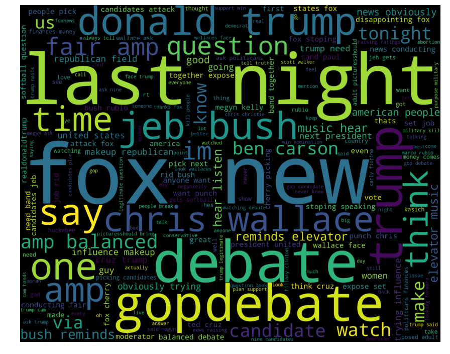

```python
wordcloud = WordCloud(stopwords=STOPWORDS,width=2500,height=2000).generate(texto)
plt.figure(figsize=(15,15))
plt.imshow(wordcloud, interpolation='bilinear')
plt.axis('off')
plt.show()
```

Vamos a visualizar las palabras distinguiendo por sentimiento:

```python
texto_positivo=datos['text'][datos['sentiment']=='Positive'].str.cat(sep=' ')
texto_negativo=datos['text'][datos['sentiment']=='Negative'].str.cat(sep=' ')
texto_neutral=datos['text'][datos['sentiment']=='Neutral'].str.cat(sep=' ')
```

```
Palabras Positivas
```

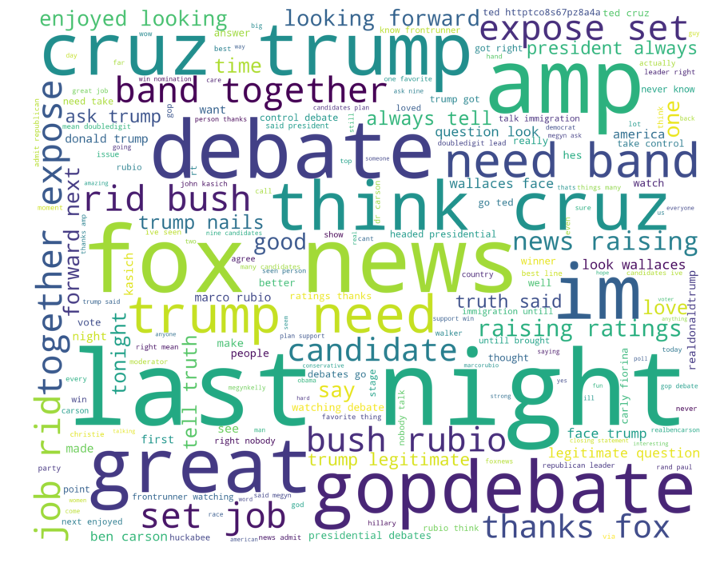

```
Palabras Neutrales
```

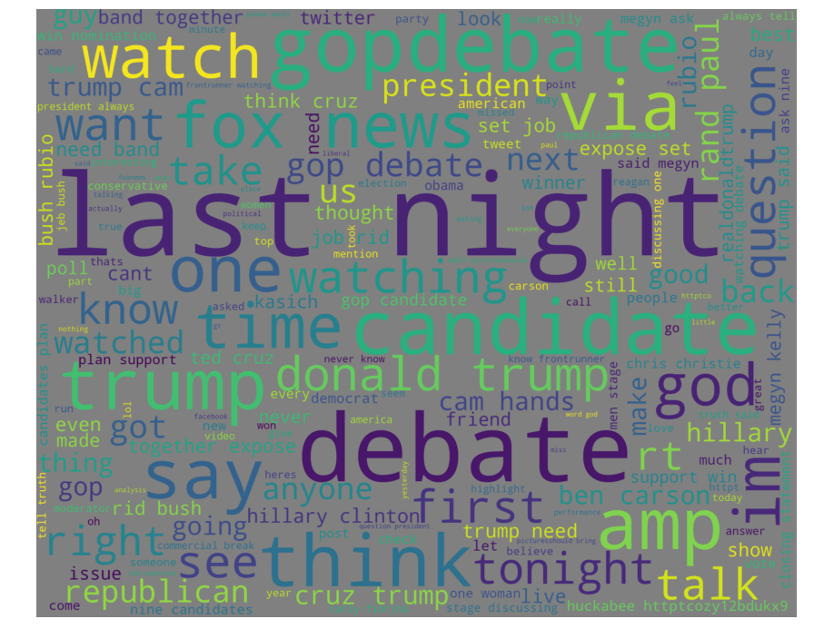

```
Palabras Negativas
```

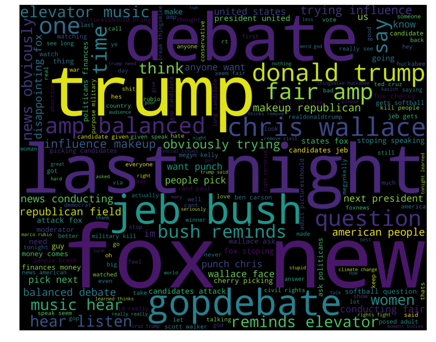

```python
print('Palabras Positivas')
wordcloud = WordCloud(stopwords=STOPWORDS,width=2500,height=2000,background_color='white').generate(texto_positivo)
plt.figure(figsize=(15,15))
plt.imshow(wordcloud, interpolation='bilinear')
plt.axis('off')
plt.show()

print('Palabras Neutrales')
wordcloud = WordCloud(stopwords=STOPWORDS,width=2500,height=2000,background_color='grey').generate(texto_neutral)
plt.figure(figsize=(15,15))
plt.imshow(wordcloud, interpolation='bilinear')
plt.axis('off')
plt.show()

print('Palabras Negativas')
wordcloud = WordCloud(stopwords=STOPWORDS,width=2500,height=2000,background_color='black').generate(texto_negativo)
plt.figure(figsize=(15,15))
plt.imshow(wordcloud, interpolation='bilinear')
plt.axis('off')
plt.show()
```

```python
datos['sentiment'].value_counts()
```

```
Negative    8493
Neutral     3142
Positive    2236
Name: sentiment, dtype: int64
```

### Modelización

Por sencillez de la explicación, voy a considerar sólo tweets positivos y negativos:

```python
data = datos[datos['sentiment'] != 'Neutral']
data.head()
```

|  | text | sentiment |
| --- | --- | --- |
| 1 | catch full last night scotts best lines 90 sec... | Positive |
| 3 | carly fiorina trending hours debate men just... | Positive |
| 4 | w delivered highest ratings history presidenti... | Positive |
| 5 | on first day rescind every illegal executive ... | Positive |
| 6 | liked happy heard going moderator anymore https | Negative |

```python
data['sentiment'].value_counts()
```

```
Negative    8493
Positive    2236
Name: sentiment, dtype: int64
```

Voy a separar en train y test, guardándome el 10% para test.

```python
from sklearn.model_selection import train_test_split
train, test = train_test_split(data, test_size=0.1)
```

Voy a obtener la tf-idf de cada término. (https://es.wikipedia.org/wiki/Tf-idf )

```python
from sklearn.feature_extraction.text import TfidfVectorizer
tfidf = TfidfVectorizer(max_features=1500, lowercase=True, analyzer='word', stop_words='english', ngram_range=(1,1))

train_tfidf = tfidf.fit_transform(train['text'])
```

```python
print(train_tfidf)
```

```
  (0, 633)	0.346161215476399
  (0, 126)	0.2779070067723267
  (0, 214)	0.25239535773456984
  (0, 1159)	0.28918783001910864
  (0, 1400)	0.39036810851858283
  (0, 1302)	0.40131737677163093
  (0, 312)	0.3786012713155966
  (0, 1327)	0.2981290552015308
  (0, 1151)	0.24890188579746922
  (0, 913)	0.21907119585127247
  (1, 877)	0.4659292548729202
  (1, 233)	0.6620032554224101
  (1, 1190)	0.5870788867466591
  (2, 1289)	0.7570472440797896
  (2, 1332)	0.30437230888350086
  (2, 789)	0.3110143828287716
  (2, 1217)	0.29489909193131647
  (2, 442)	0.38799683899207915
  (3, 126)	0.2883011867768535
  (3, 214)	0.26183536002551344
  (3, 551)	0.4254659031048661
  (3, 1033)	0.3471977806479325
  (3, 453)	0.26439210617303266
  (3, 583)	0.34263643893186124
  (3, 580)	0.3670503115407671
  :	:
  (9650, 1316)	0.3737761092043913
  (9651, 335)	0.3625242487315864
  (9651, 1440)	0.4814549249949975
  (9651, 755)	0.47825602801131606
  (9651, 523)	0.638786737456641
  (9652, 557)	0.3777791638835819
  (9652, 1008)	0.4211120001302811
  (9652, 1476)	0.44727837550182364
  (9652, 655)	0.5142439940041418
  (9652, 1003)	0.4641581154313837
  (9653, 437)	0.6454091472039359
  (9653, 1422)	0.5808127114757353
  (9653, 1491)	0.49608832569784617
  (9654, 560)	0.2689316637299886
  (9654, 938)	0.30854210485045674
  (9654, 722)	0.22409132844371338
  (9654, 686)	0.24429453411121269
  (9654, 362)	0.40196047594506884
  (9654, 1459)	0.3712718062831134
  (9654, 1288)	0.3227463565762737
  (9654, 883)	0.3634294572757994
  (9654, 159)	0.4323420259884922
  (9655, 808)	0.4815010011671073
  (9655, 588)	0.568085704252657
  (9655, 1378)	0.6674094833749636
```

```python
train_tfidf
```

```
<9656x1500 sparse matrix of type '<class 'numpy.float64'>'
	with 53787 stored elements in Compressed Sparse Row format>
```

Nos da una `sparse matrix`.

Es una matriz normal, sus filas corresponden a los tweets y sus columnas a cada una de las posibles palabras, por ejemplo:

```python
tfidf.get_feature_names()[633]
```

```
'hope'
```

El término $(d,t)$ es $\mathrm{tfidf}(t,d)$. Como casi todo son ceros en esta matriz, es más sencillo decir simplemente lo que valen los términos que no son ceros, esto es una `sparse matrix`. Esta matriz será el '$X$' de nuestro modelo.

Nuestro modelo será un Clasificador Bayesiano Ingenuo:

```python
from sklearn.naive_bayes import GaussianNB

# Definimos
gnb=GaussianNB()
# Ajustamos
gnb.fit(train_tfidf.toarray(),train['sentiment'])
```

```
GaussianNB(priors=None, var_smoothing=1e-09)
```

Para predecir, hay que sacar también la tf-idf del test set:

```python
tfidf = TfidfVectorizer(max_features=1500, lowercase=True, analyzer='word', stop_words='english', ngram_range=(1,1))

test_tfidf = tfidf.fit_transform(test['text'])
```

```python
# Predecimos
pred = gnb.predict(test_tfidf.toarray())
```

```python
test['sentiment_pred']=pred
test
```

|  | text | sentiment | sentiment_pred |
| --- | --- | --- | --- |
| 709 | know debate definitely award best live tweeting | Positive | Negative |
| 3687 | surprised learn ben carson part last night | Negative | Negative |
| 12257 | candidates attack fox stoping speaking | Negative | Negative |
| 2899 | scottwalker own although debacle | Positive | Positive |
| 5157 | me panel last nights seem little snide | Negative | Positive |
| 511 | god amp religion important election religion p... | Negative | Negative |
| 1180 | leaders lobbied prevent military commanders as... | Negative | Negative |
| 534 | billhemmer ask romney moment passed would aske... | Negative | Negative |
| 2910 | mortified ignorance republican frontrunners ri... | Negative | Negative |
| 1405 | bottom line vote candidates last night | Positive | Positive |
| 10130 | gopdebates none answered questions directly | Negative | Negative |
| 11020 | cant believe ted cruz referenced reagan hostag... | Negative | Negative |
| 12314 | would never know frontrunner watching debate | Negative | Negative |
| 13327 | fox news admit republican leader right mean do... | Negative | Negative |
| 8127 | big problem facing democrats get hillary sober... | Negative | Negative |
| 4098 | duyguozsoyler rt comicriffs sketches ted cruz ... | Positive | Negative |
| 2489 | shocked muchbut debate questions absurdwith sh... | Negative | Negative |
| 9409 | need order another green apple martini process... | Negative | Negative |
| 13860 | people say usually antisocial programs know so... | Negative | Negative |
| 6356 | about stupidity everyone named trump went http... | Negative | Positive |
| 10604 | disappointing fox news conducting fair amp bal... | Negative | Negative |
| 9490 | walker god cutting uw budget talk him | Negative | Negative |
| 8630 | american people pick next president united sta... | Negative | Negative |
| 2398 | howard kurtz bragged abt liberals sch huffpo c... | Negative | Negative |
| 11145 | candidates attack fox stoping speaking | Negative | Negative |
| 13756 | fox cherry picking candidates jeb gets softbal... | Negative | Negative |
| 1791 | great think republican party whole thing grea... | Positive | Negative |
| 3697 | gopdebate ted cruz make name saying americans ... | Positive | Negative |
| 4613 | donald trump admits national tv bought candida... | Negative | Positive |
| 405 | chris cristie re abortions absurd | Negative | Negative |
| ... | ... | ... | ... |
| 11650 | ask trump legitimate question look wallaces fa... | Positive | Negative |
| 11737 | cancel primaries fox party set amp anointed ma... | Negative | Negative |
| 2102 | lol course do rtsallykohn think won | Negative | Negative |
| 1225 | bobbyjindal brags antichoice state is report 2... | Negative | Negative |
| 2040 | deny existence something shaped country planni... | Negative | Negative |
| 11541 | thanks fox news raising s ratings | Negative | Negative |
| 10910 | playing yoshi made yarn whole world made yarn | Negative | Positive |
| 6675 | tamronhall takeaway last nights isits pseudore... | Negative | Negative |
| 1951 | genuinely impressed by thanks thoughtful quest... | Positive | Negative |
| 8983 | id really like see long candidate given speak ... | Negative | Positive |
| 12878 | donald trump obviously hearing loss upper end ... | Negative | Positive |
| 1581 | frank luntz great news ted cruz httpstcolzwvlu... | Positive | Positive |
| 8580 | posed adult picturesshould bring up | Negative | Negative |
| 11071 | russia endorses sending arms ukraine | Negative | Positive |
| 11011 | like crazy interracial thing militarynot socia... | Negative | Positive |
| 9198 | enjoyed looking forward next | Positive | Negative |
| 9601 | even mean quality production makes foxnews loo... | Negative | Positive |
| 4244 | debate attacking missing mark although enterta... | Negative | Negative |
| 6146 | we win anymore lose china lose mexico lose eve... | Positive | Negative |
| 7218 | reviewbush kasich ehhuckabee christie ok wante... | Positive | Negative |
| 1495 | second mostretweeted presidential candidate tw... | Positive | Negative |
| 13154 | politicians former government employees really... | Negative | Negative |
| 11277 | debate like bunch high school girls viciously ... | Negative | Negative |
| 2707 | hug thought punched or guess thats teachers | Negative | Negative |
| 11685 | need take control debate it | Negative | Positive |
| 2128 | trump got trumped do whines like mamas boy cal... | Negative | Negative |
| 3733 | marco rubio presidential hes articulate bright... | Positive | Negative |
| 11156 | chris wallace ask politicans finances money co... | Negative | Negative |
| 11713 | hmm chapter bible says guns | Negative | Negative |
| 9717 | id really like see long candidate given speak ... | Negative | Positive |

1073 rows × 3 columns

```python
test['sentiment'].value_counts()
```

```
Negative    836
Positive    237
Name: sentiment, dtype: int64
```

```python
test['sentiment_pred'].value_counts()
```

```
Negative    746
Positive    327
Name: sentiment_pred, dtype: int64
```

```python
print('Número de puntos mal asignados de un total de %d puntos: %d' % (len(pred),(pred!= test['sentiment']).sum()) )
```

```
Número de puntos mal asignados de un total de 1073 puntos: 416
```

Podríamos calcular métricas, usar otros clasificadores, etc.